# Worksheet 4

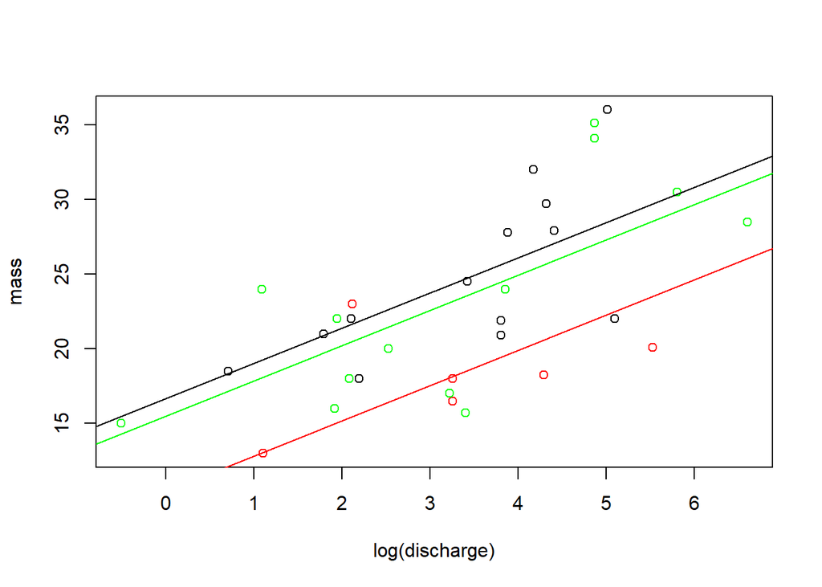

```r
#

pop.col<-hucho$population
levels(pop.col)<-c("black","red","green")
pop.col<-as.character(pop.col) # needed to get rid of "factor" attribute

plot(mass~log(discharge),data=hucho,col=pop.col)
abline(a=coef(humo4)[1],b=coef(humo4)[2],col="black")
abline(a=coef(humo4)[1]+coef(humo4)[3],b=coef(humo4)[2],col="red")
abline(a=coef(humo4)[1]+coef(humo4)[4],b=coef(humo4)[2],col="green")
```

```r
# checking assumptions
shapiro.test(humo4$res)
```

```
##
##  Shapiro-Wilk normality test
##
## data:  humo4$res
## W = 0.9575, p-value = 0.2344
```

```r
bartlett.test(humo4$res~hucho$population)
```

```
##
##  Bartlett test of homogeneity of variances
##
## data:  humo4$res by hucho$population
## Bartlett's K-squared = 0.55187, df = 2, p-value = 0.7589
```

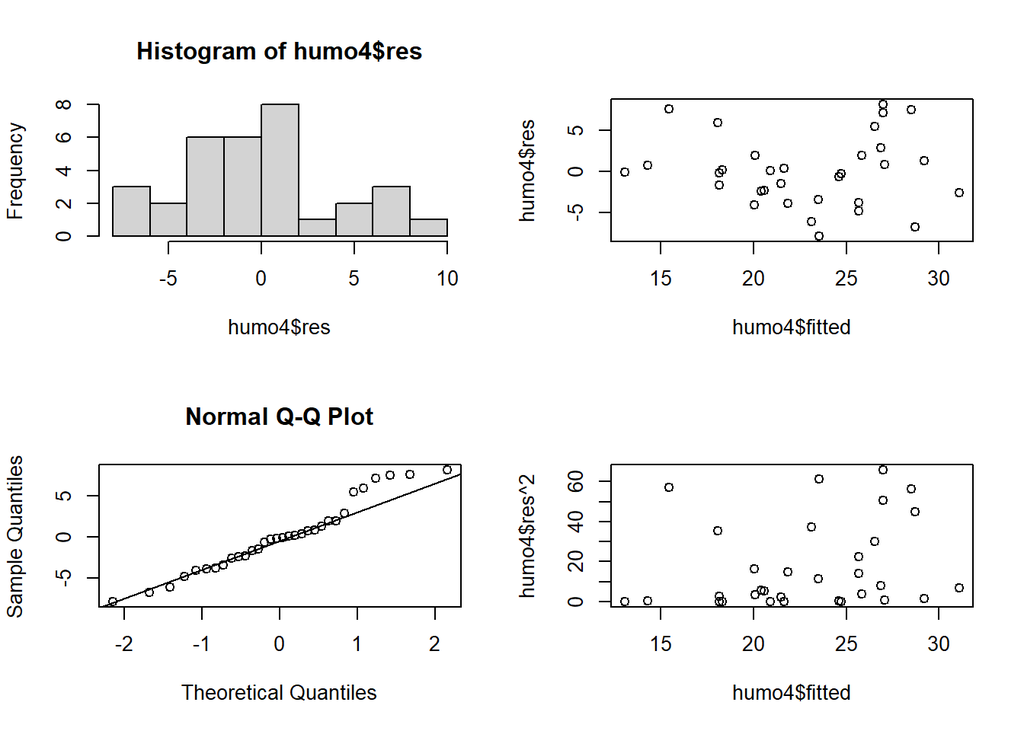

```r
layout(matrix(1:4,2,2))
hist(humo4$res)
qqnorm(humo4$res); qqline(humo4$res)

plot(humo4$res~humo4$fitted) # unexplained relationship/pattern left?
plot(humo4$res^2~humo4$fitted) # variances homogeneous? should not show any trend
```

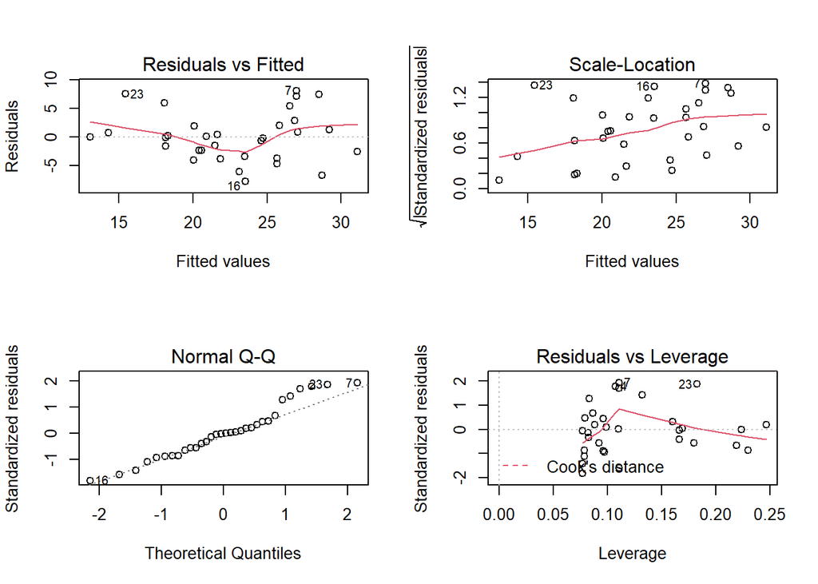

```r
layout(matrix(1:4,2,2))
plot(humo4)
```

The best model to estimate fish ladder dimension comes from mass~log(Q) using only data from large populations:

Hucho model4: Fish mass = 16.67 +2.36 log(Q)

which has similar slope but higher intercept than the model that ignores population size:

Hucho model1: Fish mass = 14.9+2.4 * log(Q)

With model1 fish would be estimated too small, fish passes would not support the largest fish that we could hope for in eventually healthy populations.